# US Health Insurance Premiums Analysis

Christopher Prasetya Mulya

2023-12-19

## Introduction

This analysis aims to model individuals health insurance charges in the United States based on several demographic indicators, namely: BMI, Region, Smoker, Children, Sex, and Age.

## Setup

Splitting randomized data into 2/3 train and 1/3 test set.

```r
set.seed(4)
insurance_data <- read.csv("insurance.csv", stringsAsFactors=TRUE)
print(summary(insurance_data))
```

```
##       age            sex           bmi           children     smoker
##  Min.   :18.00   female:662   Min.   :15.96   Min.   :0.000   no :1064
##  1st Qu.:27.00   male  :676   1st Qu.:26.30   1st Qu.:0.000   yes: 274
##  Median :39.00                Median :30.40   Median :1.000
##  Mean   :39.21                Mean   :30.66   Mean   :1.095
##  3rd Qu.:51.00                3rd Qu.:34.69   3rd Qu.:2.000
##  Max.   :64.00                Max.   :53.13   Max.   :5.000
##        region       charges
##  northeast:324   Min.   : 1122
##  northwest:325   1st Qu.: 4740
##  southeast:364   Median : 9382
##  southwest:325   Mean   :13270
##                  3rd Qu.:16640
##                  Max.   :63770
```

```r
data_randomized <- sample(insurance_data)

#setting up training and testing set
d_train <- data_randomized[1:(2*length(data_randomized$charges)/3),]
d_test <- data_randomized[(2*length(data_randomized$charges)/3+1):(length(data_randomized$charges)),]
```

### Linear Model

```r
lm_insu_reg <- lm(charges~., data=d_train)
summary(lm_insu_reg)
```

```
##
## Call:
## lm(formula = charges ~ ., data = d_train)
##
## Residuals:
##      Min       1Q   Median       3Q      Max
## -11216.1  -2806.9   -861.2   1307.5  24938.4
##
## Coefficients:
##                  Estimate Std. Error t value Pr(>|t|)
## (Intercept)     -11968.80    1208.90  -9.901   <2e-16 ***
## bmi                344.80      34.54   9.984   <2e-16 ***
## regionnorthwest   -326.56     575.88  -0.567   0.5708
## regionsoutheast  -1083.18     564.02  -1.920   0.0551 .
## regionsouthwest   -919.89     571.83  -1.609   0.1080
## smokeryes        24110.11     501.28  48.097   <2e-16 ***
## children           400.41     167.66   2.388   0.0171 *
## sexmale           -595.33     399.69  -1.489   0.1367
## age                256.64      14.11  18.183   <2e-16 ***
## ---
## Signif. codes:  0 '***' 0.001 '**' 0.01 '*' 0.05 '.' 0.1 ' ' 1
##
## Residual standard error: 5935 on 883 degrees of freedom
## Multiple R-squared:  0.7614, Adjusted R-squared:  0.7592
## F-statistic: 352.2 on 8 and 883 DF,  p-value: < 2.2e-16
```

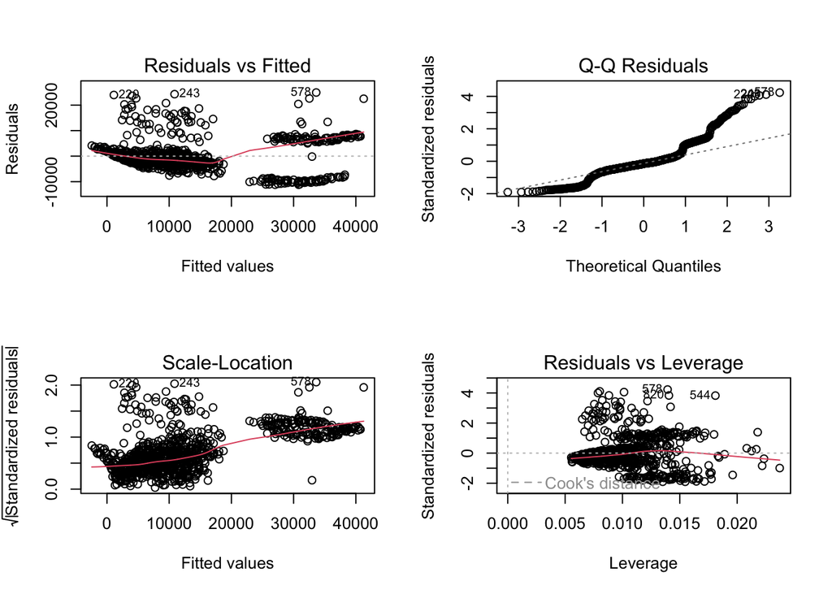

```r
par(mfrow = c(2, 2))
plot(lm_insu_reg)
```

```r
par(mfrow = c(1, 1))

cvlm <- list()
msecv <- NA
for(i in 1:nrow(d_train)){
  cvlm[[i]] <- lm(charges~., data=d_train[-i,])
  msecv[i] <- (predict(cvlm[[i]], newdata=d_train[i,]) - d_train$charges[[i]])^2
}
lm_cv_MSE <- mean(msecv)
sprintf("CV MSE estimate for linear model on training data: %s", round(lm_cv_MSE, digits=3))
```

```
## [1] "CV MSE estimate for linear model on training data: 35678999.236"
```

```r
predicted_vals_test <- predict(lm_insu_reg, newdata = d_test)
lm_test_MSE <- mean((d_test$charges - predicted_vals_test)^2)
sprintf("MSE estimate for linear model on testing data: %s", round(lm_test_MSE, digits=3))
```

```
## [1] "MSE estimate for linear model on testing data: 40020943.282"
```

Based on the regression plots, the residuals don’t seem independent or normally distributed or have constant variance which violate many of the assumptions necessary to fit a linear model.

### Lasso

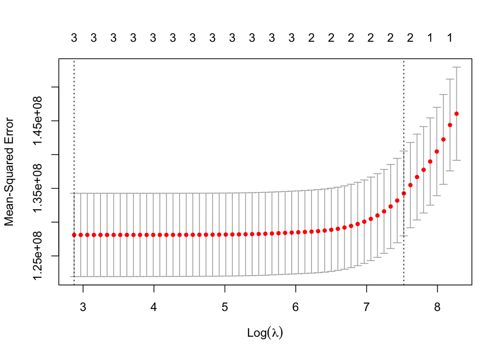

```r
x <- as.matrix(d_train[, -2])
y <- as.vector(d_train[, 2])


lasso_reg <- cv.glmnet(x,y, alpha = 1, lamda = lambda_values)
plot(lasso_reg)
```

```r
lasso_cv_mse <- min(lasso_reg$cvm)
print(lasso_cv_mse)
```

```
## [1] 128107020
```

```r
best_lasso_reg <- glmnet(x, y, alpha = 1, lambda = lasso_reg$lambda.min)

predicted_vals_test <- predict(best_lasso_reg, newx = as.matrix(d_test[,-2]))
lasso_test_MSE <- mean((d_test$charges - predicted_vals_test)^2)
sprintf("MSE estimate for Lasso regression on testing data: %s", round(lasso_test_MSE, digits=3))
```

```
## [1] "MSE estimate for Lasso regression on testing data: 133521776.277"
```

### Trees

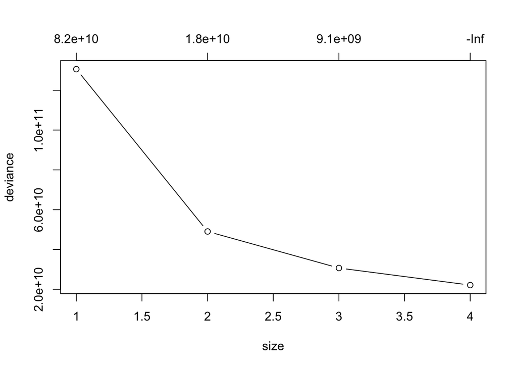

```r
tree_insu_reg <- tree(charges~., data = d_train)

set.seed(51341)
tree_insu_cv <- cv.tree(tree_insu_reg)
plot(tree_insu_cv, type="b")
```

```r
print("No pruning needed")
```

```
## [1] "No pruning needed"
```

```r
tree_cv_MSE <- min(tree_insu_cv$dev)/length(insurance_data$charges)
sprintf("Tree CV MSE estimate based on training data: %s", round(tree_cv_MSE,digits=3)) # Tree CV MSE Estimate
```

```
## [1] "Tree CV MSE estimate based on training data: 16522123.162"
```

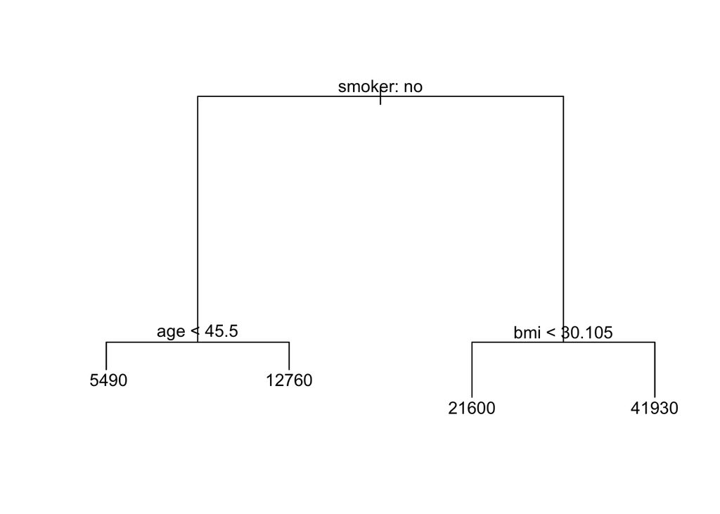

```r
plot(tree_insu_reg)
text(tree_insu_reg, pretty=0)
```

```r
summary(tree_insu_reg)
```

```
##
## Regression tree:
## tree(formula = charges ~ ., data = d_train)
## Variables actually used in tree construction:
## [1] "smoker" "age"    "bmi"
## Number of terminal nodes:  4
## Residual mean deviance:  24120000 = 2.142e+10 / 888
## Distribution of residuals:
##    Min. 1st Qu.  Median    Mean 3rd Qu.    Max.
##   -9381   -3101   -1037       0    1202   22990
```

```r
predicted_vals_test <- predict(tree_insu_reg, newdata = d_test)
tree_test_MSE <- mean((d_test$charges - predicted_vals_test)^2)

sprintf("Tree MSE estimate based on testing data: %s", round(tree_test_MSE,digits=3))
```

```
## [1] "Tree MSE estimate based on testing data: 28823125.572"
```

### Random Forest

```r
RF_insu_reg <- randomForest(charges~., data=d_train, mtry=4, importance=TRUE)
print(RF_insu_reg)
```

```
##
## Call:
##  randomForest(formula = charges ~ ., data = d_train, mtry = 4,      importance = TRUE)
##                Type of random forest: regression
##                      Number of trees: 500
## No. of variables tried at each split: 4
##
##           Mean of squared residuals: 21319469
##                     % Var explained: 85.41
```

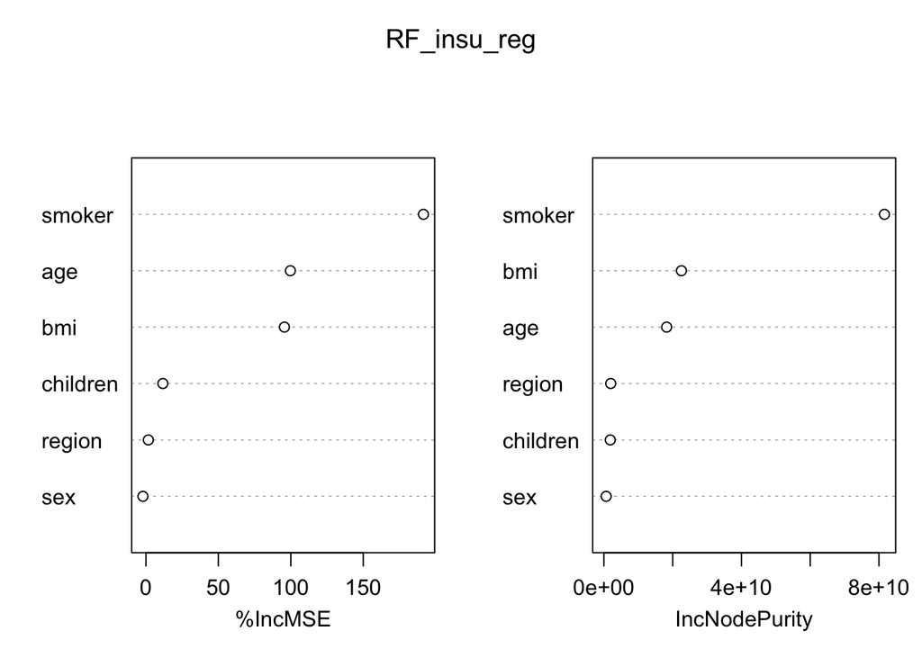

```r
varImpPlot(RF_insu_reg)
```

```r
RF_cv_MSE <- RF_insu_reg$mse[500]
sprintf("Random forest MSE estimate based on OOB estimates from training data: %s",RF_cv_MSE)
```

```
## [1] "Random forest MSE estimate based on OOB estimates from training data: 21319469.2140666"
```

```r
predicted_vals_test <- predict(RF_insu_reg, newdata = d_test)
RF_test_MSE <- mean((d_test$charges - predicted_vals_test)^2)

sprintf("Tree MSE estimate based on testing data: %s", round(RF_test_MSE,digits=3))
```

```
## [1] "Tree MSE estimate based on testing data: 23890949.266"
```

### Boosting

```r
boost_insu_reg <- gbm(charges~., distribution="gaussian", data=d_train, n.trees=5000, interaction.depth=4, shrinkage = 0.001)

# Create a training control object for cross-validation
ctrl <- trainControl(method = "cv", number = 20)  # 5-fold cross-validation

# Use the train function from caret for cross-validation
cv_results <- train(charges ~ ., data = d_train, method = "gbm", trControl = ctrl, verbose = FALSE)

# Access the cross-validated error values
boost_cv_MSE <- mean(cv_results$results$RMSE^2)
sprintf("Boosted CV MSE estimate based on training data: %s",boost_cv_MSE)
```

```
## [1] "Boosted CV MSE estimate based on training data: 24635257.3156289"
```

```r
predicted_vals_test <- predict(boost_insu_reg, newdata = d_test)
```

```
## Using 5000 trees...
```

```r
boost_test_MSE <- mean((d_test$charges - predicted_vals_test)^2)
sprintf("Boosted MSE estimate based on testing data: %s",boost_test_MSE)
```

```
## [1] "Boosted MSE estimate based on testing data: 22739702.4477322"
```

| Model | CV MSE | Test MSE |
| --- | --- | --- |
| Linear Model | 3.5678999^{7} | 4.0020943^{7} |
| Lasso | 1.2810702^{8} | 1.3352178^{8} |
| Trees | 1.6522123^{7} | 2.8823126^{7} |
| Random Forest | 2.1319469^{7} | 2.3890949^{7} |
| Boosting | 2.4635257^{7} | 2.2739702^{7} |

However, in consulting with an insurance company on this dataset, I would choose the Decision Tree model. The Decision Tree’s inherent simplicity and interpretability make it an ideal choice for stakeholders, including vendors and non-technical personnel, to easily comprehend and trust the decision-making process. In the context of health insurance charges, a Decision Tree provides a clear and transparent representation of the factors influencing the predictions, facilitating straightforward understanding of how demographic features impact charges. While other advanced models like Random Forests or Boosting may offer improved predictive accuracy, the Decision Tree strikes a balance by providing a concise and intuitive model that aligns well with the need for transparent decision-making in the insurance industry, ultimately enhancing the model’s acceptance and utility within the organization.